# Machine Learning Online Workshop

In this online workshop we will discuss about everything that you need to learn as a beginner in the field Machine Learning. This workshop targets School goers, Undergraduates, Professionals and anyone interested on Artificial Intelligence, Machine Learning, Deep learning or any related fields and the beginners in the field.

Firstt I will introduce you the concepts Artificial Intelligence, Machine Learning, Deep Learing and their differences. Then we will discuss about Machine Learning Algorithms and how they work. Thereafter how to apply real world problems to Machine Learning algorithms, how to Train and Evaluate Machine Learning algorithms and finally how to use a trained Machine Learning algorithms to obtain real time predictions. At the last part of the workshop we will train, evaluate and test a machine learning algorithm practically using Python and some other contributed modules.

# AI ML & DL

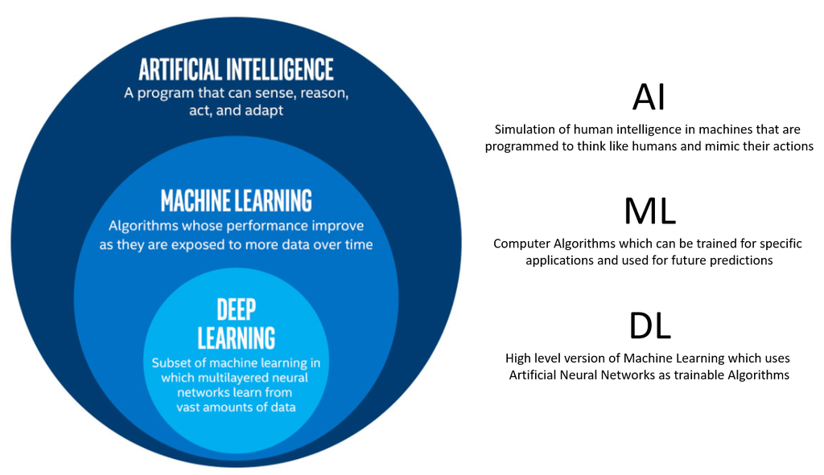

# Bit More about Machine Learning

Machine learning is an application of artificial intelligence (AI) that provides systems the ability to automatically learn and improve from experience without being explicitly programmed. Machine learning focuses on the development of computer programs that can access data and use it learn for themselves.

The process of learning begins with observations or data, such as examples, direct experience, or instruction, in order to look for patterns in data and make better decisions in the future based on the examples that we provide. The primary aim is to allow the computers learn automatically without human intervention or assistance and adjust actions accordingly. [source](https://expertsystem.com/machine-learning-definition/)

## More Mathematical Definition

A program is said to learn from **experience E** with respect to **task** T and **performance measure P**, if it’s performance at **tasks in T**, as measured by **P**, improves with **experience E**.

# Main Categories of ML

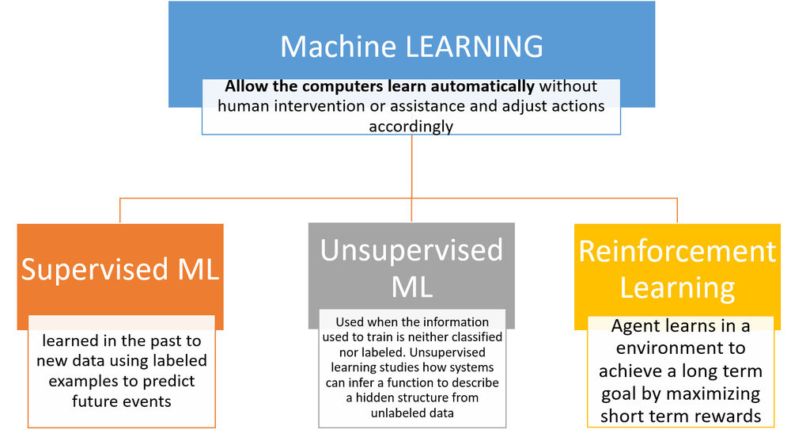

examples:

1. Supervised: Learn to swim with the guidance of an instructor
2. Unsupervised: Learn to swim by self studying
3. Reinforcement: Dropping off in the middle of the sea to learn swimming

# Supervised ML

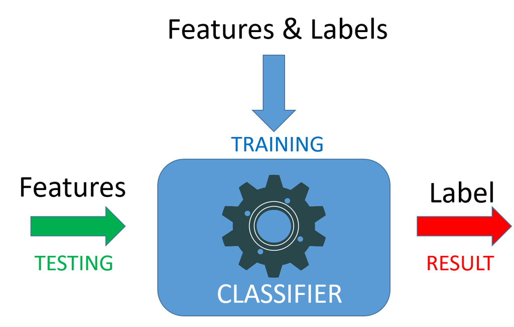

# Features and Labels

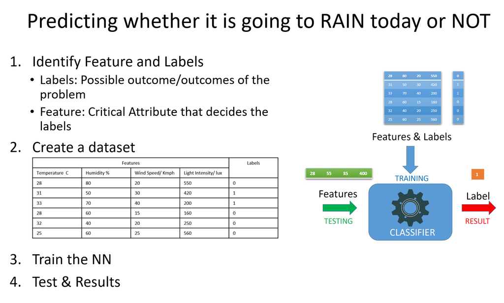

# Classification & Regression

1. **Classification:** “Classification" indicates that the data has discrete class label. Classification predictive modeling is the task of approximating a mapping function (f) from input variables (X) to discrete output variables (y) or classes. The output variables are often called labels or categories. The mapping function predicts the class or category for a given observation
2. **Regression:** Regression predictive modeling is the task of approximating a mapping function (f) from input variables (X) to a continuous output variable (y). A continuous output variable is a real-value, such as an integer or floating point value. These are often quantities, such as amounts and sizes. For example, a house may be predicted to sell for a specific dollar value, perhaps in the range of $100,000 to $200,000.

# ML Algorithms

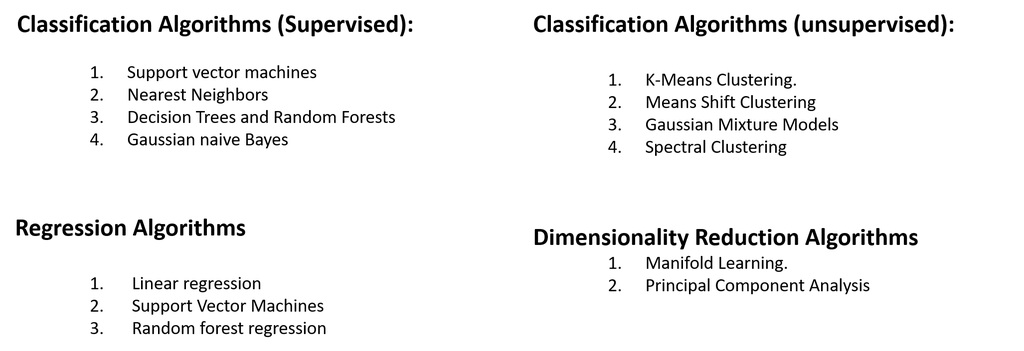

# Our Problem

Training, Evaluating and Testing a Machine Learing Algorithm to Identify Handwritten Digits.

## 1. Identifying Features and Labels

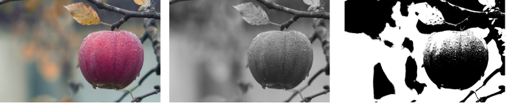

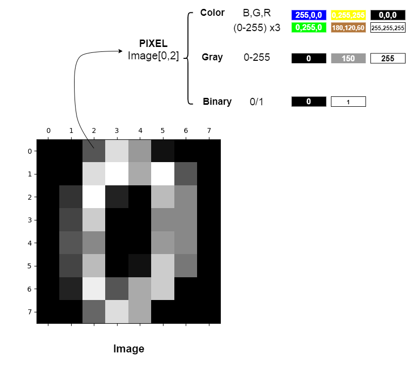

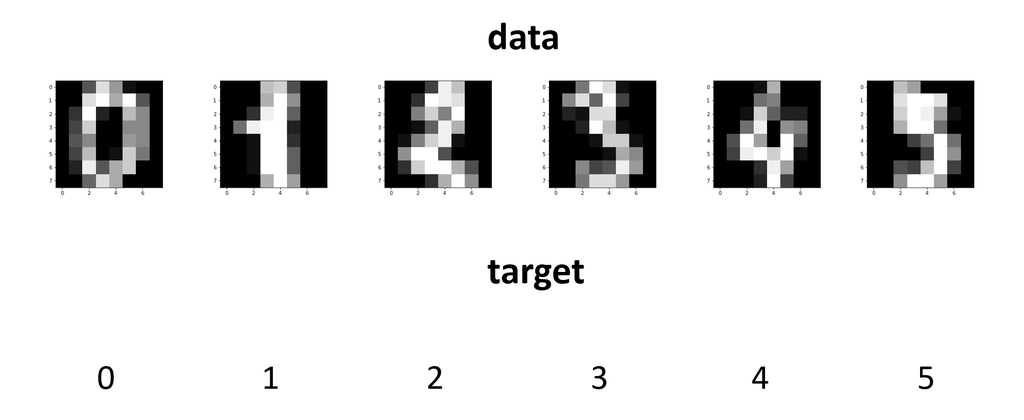

## 2. Dataset

Sklearn Inbuilt Digits Dataset

```python
from sklearn.datasets import load_digits
#importing the load_digits method from datasets sub module in sklearn module

dataset=load_digits()

data=dataset.data
images=dataset.images
target=dataset.target

print('data shape:',data.shape)
print('images shape:',images.shape)
print('data shape:',target.shape)
```

```
data shape: (1797, 64)
images shape: (1797, 8, 8)
data shape: (1797,)
```

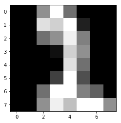

```python
from matplotlib import pyplot as plt

plt.imshow(images[1016],cmap='gray')
```

```python
print(images[1016])
```

```
[[ 0.  0.  9. 16.  7.  0.  0.  0.]
 [ 0.  0. 14. 13. 16.  2.  0.  0.]
 [ 0.  0.  7.  9. 15.  8.  0.  0.]
 [ 0.  0.  0.  1. 13.  9.  0.  0.]
 [ 0.  0.  0.  0. 14.  7.  0.  0.]
 [ 0.  0.  0.  4. 16.  5.  0.  0.]
 [ 0.  0.  7. 16. 16.  8.  6.  0.]
 [ 0.  0.  9. 15. 12. 16. 16.  9.]]
```

```python
print(data[1016])
```

```
[ 0.  0.  9. 16.  7.  0.  0.  0.  0.  0. 14. 13. 16.  2.  0.  0.  0.  0.
  7.  9. 15.  8.  0.  0.  0.  0.  0.  1. 13.  9.  0.  0.  0.  0.  0.  0.
 14.  7.  0.  0.  0.  0.  0.  4. 16.  5.  0.  0.  0.  0.  7. 16. 16.  8.
  6.  0.  0.  0.  9. 15. 12. 16. 16.  9.]
```

```python
print(target[1016])
```

```
2
```

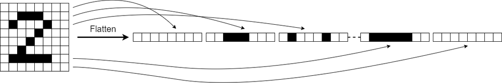

# Train Test Split

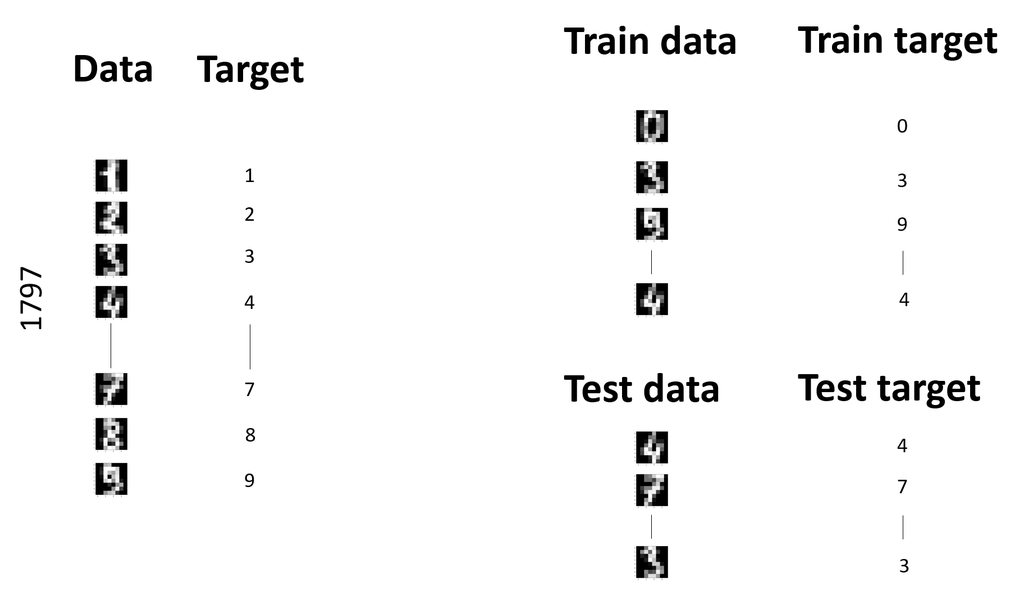

```python
from sklearn.model_selection import train_test_split

train_data,test_data,train_target,test_target=train_test_split(data,target,test_size=0.2)
```

# Training the KNN Algorithm

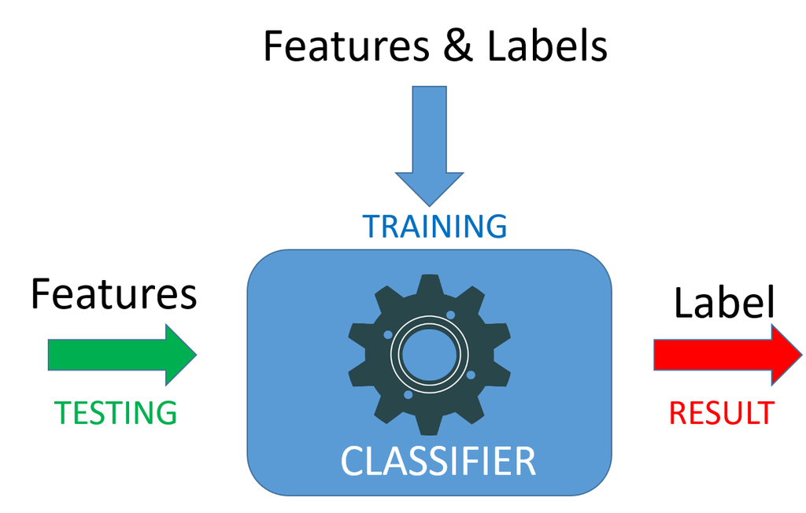

```python
from sklearn.neighbors import KNeighborsClassifier
#import KNN Algorithm

algorithm=KNeighborsClassifier(n_neighbors=3)
#New KNN Algorithm (Object)

algorithm.fit(train_data,train_target)
#training the KNN Algorithm
```

```
KNeighborsClassifier(algorithm='auto', leaf_size=30, metric='minkowski',
           metric_params=None, n_jobs=None, n_neighbors=3, p=2,
           weights='uniform')
```

```python
print('train data size:',train_data.shape)
print('test data size:',test_data.shape)
```

```
train data size: (1437, 64)
test data size: (360, 64)
```

```python
predicted_targets=algorithm.predict(test_data)
```

```python
print('Actual Targets:',test_target)
print('Predicted Targets:',predicted_targets)
```

```
Actual Targets: [3 5 9 4 2 6 1 7 3 4 3 2 4 4 3 2 8 6 1 1 9 6 7 9 9 2 8 3 4 0 4 3 5 4 6 2 9
 5 9 4 3 8 9 9 8 4 4 6 3 9 7 2 5 2 9 0 3 2 1 8 8 9 3 2 0 5 8 7 8 5 0 0 2 4
 9 2 5 8 6 9 9 3 6 7 9 1 3 2 3 0 7 8 2 5 4 1 4 1 9 5 7 4 3 1 9 8 6 2 4 4 6
 2 8 5 0 9 0 5 0 9 0 4 4 0 5 6 3 3 7 4 3 0 2 2 9 5 4 4 3 3 6 3 5 0 0 8 1 5
 2 7 4 3 4 2 2 1 2 3 0 0 1 6 7 7 6 0 1 1 9 2 3 6 6 9 8 9 0 3 4 1 0 9 4 0 3
 8 5 7 3 3 2 8 1 4 4 7 6 1 5 2 7 5 6 3 4 0 5 5 2 6 4 6 0 0 9 1 9 0 6 6 3 6
 5 8 6 3 7 0 4 0 3 9 0 2 6 4 4 4 6 9 1 8 2 1 6 4 4 0 4 4 3 8 7 6 0 0 2 4 4
 6 8 1 7 4 9 2 1 7 5 4 4 6 3 0 6 1 4 2 9 6 1 9 0 1 6 1 0 3 6 2 4 6 2 8 4 8
 0 8 7 6 0 5 3 9 7 4 1 0 5 6 7 8 7 0 3 4 5 7 8 2 3 3 2 3 0 1 6 0 7 2 3 5 3
 4 9 2 6 9 1 3 4 0 8 7 7 9 2 2 2 4 7 5 0 8 5 3 2 7 1 9]
Predicted Targets: [3 5 9 4 2 6 1 7 3 4 3 2 4 4 3 2 8 6 1 1 9 6 7 9 9 2 8 3 4 0 4 3 5 4 6 2 9
 5 9 4 3 8 9 9 8 4 4 6 3 9 7 2 5 2 9 0 3 2 1 8 8 9 3 2 0 5 8 7 8 5 0 0 2 4
 9 2 5 8 6 9 9 3 6 7 3 1 3 2 3 0 7 8 2 5 4 1 4 1 9 5 7 4 3 1 9 8 6 2 4 4 6
 2 8 5 0 9 0 5 0 9 0 4 4 0 5 6 3 3 7 4 3 0 2 2 9 5 4 4 3 3 6 3 5 0 0 8 1 5
 2 7 4 3 4 2 2 1 2 3 0 0 1 6 7 7 6 0 1 1 9 2 3 6 6 9 8 9 0 3 4 1 0 9 4 0 3
 8 5 7 3 3 2 8 1 4 4 7 6 1 5 2 7 5 6 3 4 0 5 5 2 6 4 6 0 0 9 1 9 0 6 6 3 6
 5 8 6 3 7 0 4 0 3 9 0 2 6 4 4 4 6 9 1 8 2 1 6 4 4 0 4 4 3 8 7 6 0 0 2 4 4
 6 8 1 7 4 9 2 1 7 5 4 4 6 3 0 6 1 4 2 9 6 1 9 0 1 6 1 0 3 6 2 4 6 2 8 4 8
 0 8 7 6 0 5 3 9 7 4 1 0 5 6 7 8 7 0 3 4 5 7 8 2 3 3 2 3 0 1 6 0 7 2 3 5 3
 4 9 2 6 9 1 3 4 0 8 7 7 9 2 2 2 4 7 5 0 8 5 3 2 7 1 9]
```

# Evaluating the Algorithm

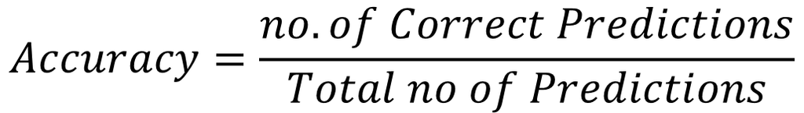

```python
from sklearn.metrics import accuracy_score

acc=accuracy_score(test_target,predicted_targets)
print('Accuracy:',acc)
```

```
Accuracy: 0.9972222222222222
```

```python
import joblib

joblib.dump(algorithm,'KNN-digits.sav')
```

```
['KNN-digits.sav']
```

# K Nearest Neighbor Algorithm (Classifier)

## Training

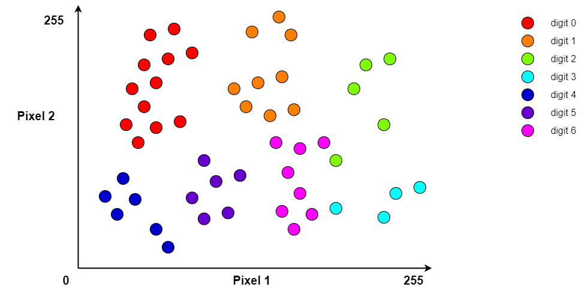

## Predicting

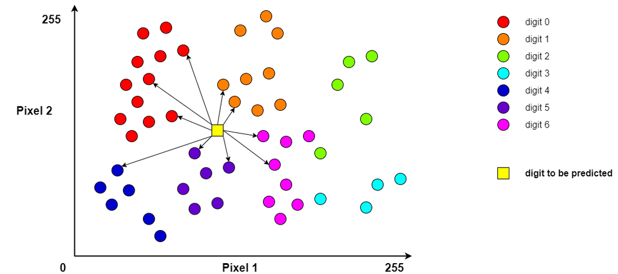

## Euclidean Disance Example

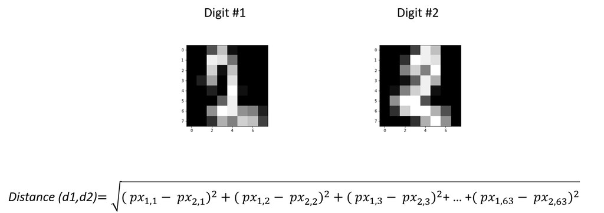

## What is K?

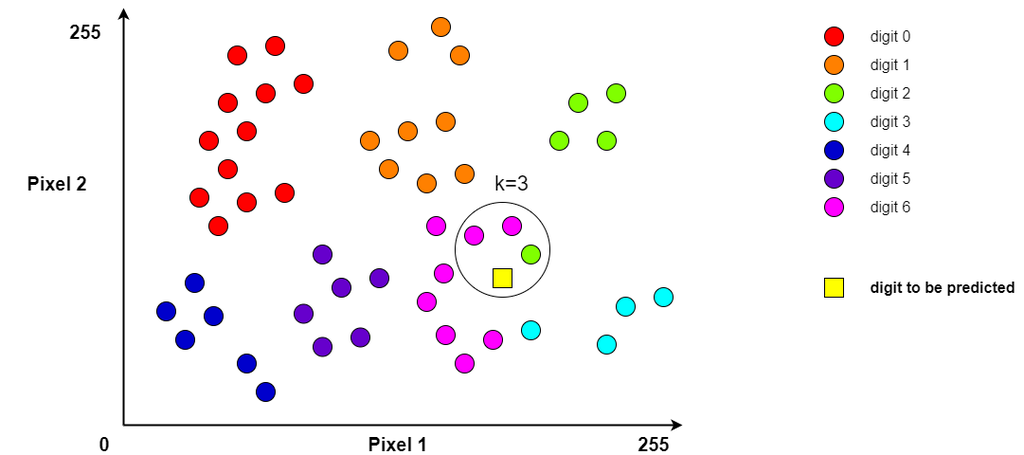

## KNN Algorithm Summary

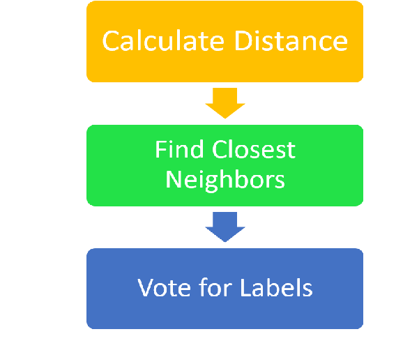